# Risk Factor Analysis

## Outcome Variable

**Outcome Variable:** ever_wasted

## Predictor Variables

**Intervention Variable:** mhtcm

**Adjustment Set:**

- arm
- W_mage
- meducyrs
- feducyrs
- delta_W_mage
- delta_meducyrs
- delta_feducyrs

## Stratifying Variables

The analysis was stratified on these variable(s):

- agecat
- studyid
- country

## Data Summary

| agecat | studyid | country | mhtcm | ever_wasted | n_cell | n |
| --- | --- | --- | --- | --- | --- | --- |
| 0-24 months | COHORTS | GUATEMALA | >=155 cm | 0 | 121 | 1275 |
| 0-24 months | COHORTS | GUATEMALA | >=155 cm | 1 | 44 | 1275 |
| 0-24 months | COHORTS | GUATEMALA | <151 cm | 0 | 605 | 1275 |
| 0-24 months | COHORTS | GUATEMALA | <151 cm | 1 | 230 | 1275 |
| 0-24 months | COHORTS | GUATEMALA | [151-155) cm | 0 | 214 | 1275 |
| 0-24 months | COHORTS | GUATEMALA | [151-155) cm | 1 | 61 | 1275 |
| 0-24 months | COHORTS | INDIA | >=155 cm | 0 | 381 | 1905 |
| 0-24 months | COHORTS | INDIA | >=155 cm | 1 | 190 | 1905 |
| 0-24 months | COHORTS | INDIA | <151 cm | 0 | 547 | 1905 |
| 0-24 months | COHORTS | INDIA | <151 cm | 1 | 276 | 1905 |
| 0-24 months | COHORTS | INDIA | [151-155) cm | 0 | 341 | 1905 |
| 0-24 months | COHORTS | INDIA | [151-155) cm | 1 | 170 | 1905 |
| 0-24 months | COHORTS | PHILIPPINES | >=155 cm | 0 | 389 | 3045 |
| 0-24 months | COHORTS | PHILIPPINES | >=155 cm | 1 | 240 | 3045 |
| 0-24 months | COHORTS | PHILIPPINES | <151 cm | 0 | 878 | 3045 |
| 0-24 months | COHORTS | PHILIPPINES | <151 cm | 1 | 662 | 3045 |
| 0-24 months | COHORTS | PHILIPPINES | [151-155) cm | 0 | 549 | 3045 |
| 0-24 months | COHORTS | PHILIPPINES | [151-155) cm | 1 | 327 | 3045 |
| 0-24 months | Guatemala BSC | GUATEMALA | >=155 cm | 0 | 33 | 235 |
| 0-24 months | Guatemala BSC | GUATEMALA | >=155 cm | 1 | 3 | 235 |
| 0-24 months | Guatemala BSC | GUATEMALA | <151 cm | 0 | 127 | 235 |
| 0-24 months | Guatemala BSC | GUATEMALA | <151 cm | 1 | 16 | 235 |
| 0-24 months | Guatemala BSC | GUATEMALA | [151-155) cm | 0 | 49 | 235 |
| 0-24 months | Guatemala BSC | GUATEMALA | [151-155) cm | 1 | 7 | 235 |
| 0-24 months | iLiNS-Zinc | BURKINA FASO | >=155 cm | 0 | 2261 | 3217 |
| 0-24 months | iLiNS-Zinc | BURKINA FASO | >=155 cm | 1 | 639 | 3217 |
| 0-24 months | iLiNS-Zinc | BURKINA FASO | <151 cm | 0 | 62 | 3217 |
| 0-24 months | iLiNS-Zinc | BURKINA FASO | <151 cm | 1 | 29 | 3217 |
| 0-24 months | iLiNS-Zinc | BURKINA FASO | [151-155) cm | 0 | 161 | 3217 |
| 0-24 months | iLiNS-Zinc | BURKINA FASO | [151-155) cm | 1 | 65 | 3217 |

[output cut: 378 more lines]

The following strata were considered:

- agecat: 0-24 months, studyid: COHORTS, country: GUATEMALA
- agecat: 0-24 months, studyid: COHORTS, country: INDIA
- agecat: 0-24 months, studyid: COHORTS, country: PHILIPPINES
- agecat: 0-24 months, studyid: Guatemala BSC, country: GUATEMALA
- agecat: 0-24 months, studyid: iLiNS-Zinc, country: BURKINA FASO
- agecat: 0-24 months, studyid: JiVitA-3, country: BANGLADESH
- agecat: 0-24 months, studyid: Keneba, country: GAMBIA
- agecat: 0-24 months, studyid: LCNI-5, country: MALAWI
- agecat: 0-24 months, studyid: MAL-ED, country: BANGLADESH
- agecat: 0-24 months, studyid: MAL-ED, country: BRAZIL
- agecat: 0-24 months, studyid: MAL-ED, country: INDIA
- agecat: 0-24 months, studyid: MAL-ED, country: NEPAL
- agecat: 0-24 months, studyid: MAL-ED, country: PERU
- agecat: 0-24 months, studyid: MAL-ED, country: SOUTH AFRICA
- agecat: 0-24 months, studyid: MAL-ED, country: TANZANIA, UNITED REPUBLIC OF
- agecat: 0-24 months, studyid: NIH-Birth, country: BANGLADESH
- agecat: 0-24 months, studyid: NIH-Crypto, country: BANGLADESH
- agecat: 0-24 months, studyid: PROBIT, country: BELARUS
- agecat: 0-24 months, studyid: PROVIDE, country: BANGLADESH
- agecat: 0-24 months, studyid: SAS-CompFeed, country: INDIA
- agecat: 0-24 months, studyid: SAS-FoodSuppl, country: INDIA
- agecat: 0-24 months, studyid: TanzaniaChild2, country: TANZANIA, UNITED REPUBLIC OF
- agecat: 0-24 months, studyid: ZVITAMBO, country: ZIMBABWE
- agecat: 0-6 months, studyid: COHORTS, country: GUATEMALA
- agecat: 0-6 months, studyid: COHORTS, country: INDIA
- agecat: 0-6 months, studyid: COHORTS, country: PHILIPPINES
- agecat: 0-6 months, studyid: Guatemala BSC, country: GUATEMALA
- agecat: 0-6 months, studyid: JiVitA-3, country: BANGLADESH
- agecat: 0-6 months, studyid: Keneba, country: GAMBIA
- agecat: 0-6 months, studyid: LCNI-5, country: MALAWI
- agecat: 0-6 months, studyid: MAL-ED, country: BANGLADESH
- agecat: 0-6 months, studyid: MAL-ED, country: BRAZIL
- agecat: 0-6 months, studyid: MAL-ED, country: INDIA
- agecat: 0-6 months, studyid: MAL-ED, country: NEPAL
- agecat: 0-6 months, studyid: MAL-ED, country: PERU
- agecat: 0-6 months, studyid: MAL-ED, country: SOUTH AFRICA
- agecat: 0-6 months, studyid: MAL-ED, country: TANZANIA, UNITED REPUBLIC OF
- agecat: 0-6 months, studyid: NIH-Birth, country: BANGLADESH
- agecat: 0-6 months, studyid: NIH-Crypto, country: BANGLADESH
- agecat: 0-6 months, studyid: PROBIT, country: BELARUS
- agecat: 0-6 months, studyid: PROVIDE, country: BANGLADESH
- agecat: 0-6 months, studyid: SAS-CompFeed, country: INDIA
- agecat: 0-6 months, studyid: SAS-FoodSuppl, country: INDIA
- agecat: 0-6 months, studyid: TanzaniaChild2, country: TANZANIA, UNITED REPUBLIC OF
- agecat: 0-6 months, studyid: ZVITAMBO, country: ZIMBABWE
- agecat: 6-24 months, studyid: COHORTS, country: GUATEMALA
- agecat: 6-24 months, studyid: COHORTS, country: INDIA
- agecat: 6-24 months, studyid: COHORTS, country: PHILIPPINES
- agecat: 6-24 months, studyid: Guatemala BSC, country: GUATEMALA
- agecat: 6-24 months, studyid: iLiNS-Zinc, country: BURKINA FASO
- agecat: 6-24 months, studyid: JiVitA-3, country: BANGLADESH
- agecat: 6-24 months, studyid: Keneba, country: GAMBIA
- agecat: 6-24 months, studyid: LCNI-5, country: MALAWI
- agecat: 6-24 months, studyid: MAL-ED, country: BANGLADESH
- agecat: 6-24 months, studyid: MAL-ED, country: BRAZIL
- agecat: 6-24 months, studyid: MAL-ED, country: INDIA
- agecat: 6-24 months, studyid: MAL-ED, country: NEPAL
- agecat: 6-24 months, studyid: MAL-ED, country: PERU
- agecat: 6-24 months, studyid: MAL-ED, country: SOUTH AFRICA
- agecat: 6-24 months, studyid: MAL-ED, country: TANZANIA, UNITED REPUBLIC OF
- agecat: 6-24 months, studyid: NIH-Birth, country: BANGLADESH
- agecat: 6-24 months, studyid: NIH-Crypto, country: BANGLADESH
- agecat: 6-24 months, studyid: PROBIT, country: BELARUS
- agecat: 6-24 months, studyid: PROVIDE, country: BANGLADESH
- agecat: 6-24 months, studyid: SAS-CompFeed, country: INDIA
- agecat: 6-24 months, studyid: SAS-FoodSuppl, country: INDIA
- agecat: 6-24 months, studyid: TanzaniaChild2, country: TANZANIA, UNITED REPUBLIC OF
- agecat: 6-24 months, studyid: ZVITAMBO, country: ZIMBABWE

### Dropped Strata

Some strata were dropped due to rare outcomes:

- agecat: 0-24 months, studyid: Guatemala BSC, country: GUATEMALA
- agecat: 0-24 months, studyid: MAL-ED, country: BRAZIL
- agecat: 0-24 months, studyid: MAL-ED, country: PERU
- agecat: 0-24 months, studyid: MAL-ED, country: SOUTH AFRICA
- agecat: 0-6 months, studyid: Guatemala BSC, country: GUATEMALA
- agecat: 0-6 months, studyid: LCNI-5, country: MALAWI
- agecat: 0-6 months, studyid: MAL-ED, country: BRAZIL
- agecat: 0-6 months, studyid: MAL-ED, country: PERU
- agecat: 0-6 months, studyid: MAL-ED, country: SOUTH AFRICA
- agecat: 0-6 months, studyid: MAL-ED, country: TANZANIA, UNITED REPUBLIC OF
- agecat: 6-24 months, studyid: Guatemala BSC, country: GUATEMALA
- agecat: 6-24 months, studyid: MAL-ED, country: BANGLADESH
- agecat: 6-24 months, studyid: MAL-ED, country: BRAZIL
- agecat: 6-24 months, studyid: MAL-ED, country: PERU
- agecat: 6-24 months, studyid: MAL-ED, country: SOUTH AFRICA
- agecat: 6-24 months, studyid: PROBIT, country: BELARUS

## Methods Detail

We're interested in the causal parameters $E[Y_a]$ for all values of $a \in \mathcal{A}$. These parameters represent the mean outcome if, possibly contrary to fact, we intervened to set all units to have $A=a$. Under the randomization and positivity assumptions, these are identified by the statistical parameters $\psi_a=E_W[E_{Y|A,W}(Y|A=a,W)]$. In addition, we're interested in the mean of $Y$, $E[Y]$ under no intervention (the observed mean). We will estimate these parameters by using SuperLearner to fit the relevant likelihood factors -- $E_{Y|A,W}(Y|A=a,W)$ and $p(A=a|W)$, and then updating our likelihood fit using a joint TMLE.

For unadjusted analyses ($W=\{\}$), initial likelihoods were estimated using Lrnr_glm to estimate the simple $E(Y|A)$ and Lrnr_mean to estimate $p(A)$. For adjusted analyses, a small library containing Lrnr_glmnet, Lrnr_xgboost, and Lrnr_mean was used.

Having estimated these parameters, we will then use the delta method to estimate relative risks and attributable risks relative to a prespecified baseline level of $A$.

# Results Detail

## Results Plots

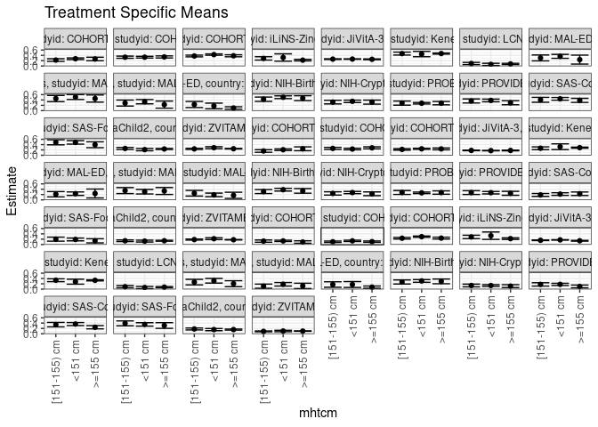

[figure not shown]

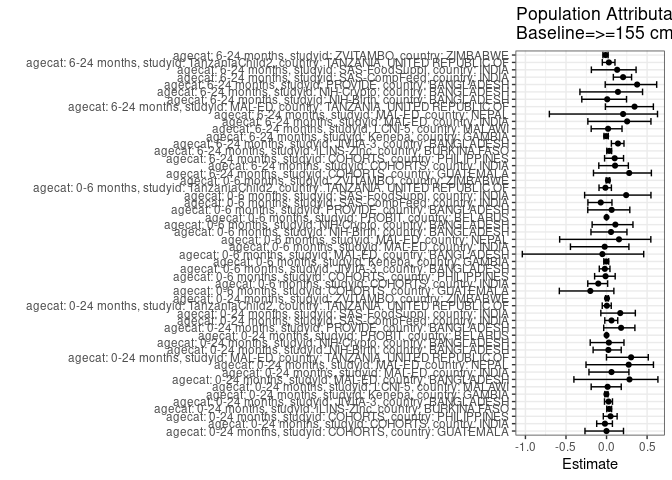

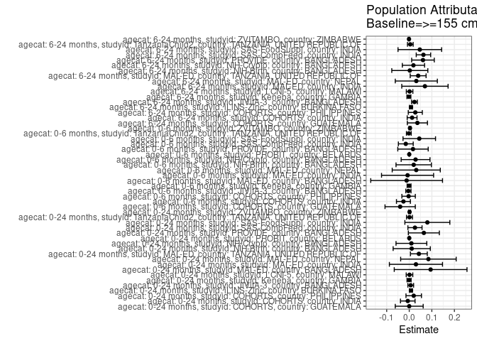

## Results Table

### Parameter: TSM

| agecat | studyid | country | intervention_level | baseline_level | estimate | ci_lower | ci_upper |
| --- | --- | --- | --- | --- | --- | --- | --- |
| 0-24 months | COHORTS | GUATEMALA | >=155 cm | NA | 0.2629240 | 0.1967087 | 0.3291393 |
| 0-24 months | COHORTS | GUATEMALA | <151 cm | NA | 0.2730109 | 0.2427249 | 0.3032970 |
| 0-24 months | COHORTS | GUATEMALA | [151-155) cm | NA | 0.2228651 | 0.1744005 | 0.2713298 |
| 0-24 months | COHORTS | INDIA | >=155 cm | NA | 0.3405335 | 0.3018844 | 0.3791827 |
| 0-24 months | COHORTS | INDIA | <151 cm | NA | 0.3309919 | 0.2987712 | 0.3632125 |
| 0-24 months | COHORTS | INDIA | [151-155) cm | NA | 0.3304602 | 0.2895007 | 0.3714198 |
| 0-24 months | COHORTS | PHILIPPINES | >=155 cm | NA | 0.3838478 | 0.3454857 | 0.4222099 |
| 0-24 months | COHORTS | PHILIPPINES | <151 cm | NA | 0.4280134 | 0.4032944 | 0.4527323 |
| 0-24 months | COHORTS | PHILIPPINES | [151-155) cm | NA | 0.3757631 | 0.3432745 | 0.4082517 |
| 0-24 months | iLiNS-Zinc | BURKINA FASO | >=155 cm | NA | 0.2203509 | 0.1914041 | 0.2492978 |
| 0-24 months | iLiNS-Zinc | BURKINA FASO | <151 cm | NA | 0.3186787 | 0.1815533 | 0.4558042 |
| 0-24 months | iLiNS-Zinc | BURKINA FASO | [151-155) cm | NA | 0.2855799 | 0.2231718 | 0.3479879 |
| 0-24 months | JiVitA-3 | BANGLADESH | >=155 cm | NA | 0.2515276 | 0.2370178 | 0.2660375 |
| 0-24 months | JiVitA-3 | BANGLADESH | <151 cm | NA | 0.2605865 | 0.2526893 | 0.2684836 |
| 0-24 months | JiVitA-3 | BANGLADESH | [151-155) cm | NA | 0.2586081 | 0.2469330 | 0.2702831 |
| 0-24 months | Keneba | GAMBIA | >=155 cm | NA | 0.4671396 | 0.4453519 | 0.4889274 |
| 0-24 months | Keneba | GAMBIA | <151 cm | NA | 0.4482192 | 0.3477480 | 0.5486904 |
| 0-24 months | Keneba | GAMBIA | [151-155) cm | NA | 0.4661294 | 0.4111936 | 0.5210651 |
| 0-24 months | LCNI-5 | MALAWI | >=155 cm | NA | 0.0778210 | 0.0546480 | 0.1009940 |
| 0-24 months | LCNI-5 | MALAWI | <151 cm | NA | 0.0610687 | 0.0200390 | 0.1020984 |
| 0-24 months | LCNI-5 | MALAWI | [151-155) cm | NA | 0.0937500 | 0.0524959 | 0.1350041 |
| 0-24 months | MAL-ED | BANGLADESH | >=155 cm | NA | 0.2400000 | 0.0722560 | 0.4077440 |
| 0-24 months | MAL-ED | BANGLADESH | <151 cm | NA | 0.3619632 | 0.2880425 | 0.4358839 |
| 0-24 months | MAL-ED | BANGLADESH | [151-155) cm | NA | 0.3030303 | 0.1919383 | 0.4141223 |
| 0-24 months | MAL-ED | INDIA | >=155 cm | NA | 0.4538557 | 0.3202504 | 0.5874609 |
| 0-24 months | MAL-ED | INDIA | <151 cm | NA | 0.5097413 | 0.4178867 | 0.6015960 |
| 0-24 months | MAL-ED | INDIA | [151-155) cm | NA | 0.4543047 | 0.3377340 | 0.5708754 |
| 0-24 months | MAL-ED | NEPAL | >=155 cm | NA | 0.2260438 | 0.0928826 | 0.3592050 |
| 0-24 months | MAL-ED | NEPAL | <151 cm | NA | 0.3354363 | 0.2548730 | 0.4159995 |
| 0-24 months | MAL-ED | NEPAL | [151-155) cm | NA | 0.2838588 | 0.1706349 | 0.3970828 |

[output cut: 126 more lines]

### Parameter: E(Y)

| agecat | studyid | country | intervention_level | baseline_level | estimate | ci_lower | ci_upper |
| --- | --- | --- | --- | --- | --- | --- | --- |
| 0-24 months | COHORTS | GUATEMALA | NA | NA | 0.2627451 | 0.2385772 | 0.2869130 |
| 0-24 months | COHORTS | INDIA | NA | NA | 0.3338583 | 0.3126757 | 0.3550409 |
| 0-24 months | COHORTS | PHILIPPINES | NA | NA | 0.4036125 | 0.3861835 | 0.4210415 |
| 0-24 months | iLiNS-Zinc | BURKINA FASO | NA | NA | 0.2278520 | 0.2008644 | 0.2548397 |
| 0-24 months | JiVitA-3 | BANGLADESH | NA | NA | 0.2580393 | 0.2515701 | 0.2645084 |
| 0-24 months | Keneba | GAMBIA | NA | NA | 0.4663106 | 0.4464881 | 0.4861331 |
| 0-24 months | LCNI-5 | MALAWI | NA | NA | 0.0788530 | 0.0605839 | 0.0971222 |
| 0-24 months | MAL-ED | BANGLADESH | NA | NA | 0.3346457 | 0.2765014 | 0.3927899 |
| 0-24 months | MAL-ED | INDIA | NA | NA | 0.4834711 | 0.4203794 | 0.5465628 |
| 0-24 months | MAL-ED | NEPAL | NA | NA | 0.3109244 | 0.2519946 | 0.3698541 |
| 0-24 months | MAL-ED | TANZANIA, UNITED REPUBLIC OF | NA | NA | 0.1406250 | 0.0979572 | 0.1832928 |
| 0-24 months | NIH-Birth | BANGLADESH | NA | NA | 0.4775641 | 0.4383415 | 0.5167867 |
| 0-24 months | NIH-Crypto | BANGLADESH | NA | NA | 0.3298013 | 0.2962438 | 0.3633589 |
| 0-24 months | PROBIT | BELARUS | NA | NA | 0.2807631 | 0.2185905 | 0.3429356 |
| 0-24 months | PROVIDE | BANGLADESH | NA | NA | 0.3602392 | 0.3238339 | 0.3966444 |
| 0-24 months | SAS-CompFeed | INDIA | NA | NA | 0.4107914 | 0.3512139 | 0.4703688 |
| 0-24 months | SAS-FoodSuppl | INDIA | NA | NA | 0.4743276 | 0.4258753 | 0.5227800 |
| 0-24 months | TanzaniaChild2 | TANZANIA, UNITED REPUBLIC OF | NA | NA | 0.2369648 | 0.2198019 | 0.2541277 |
| 0-24 months | ZVITAMBO | ZIMBABWE | NA | NA | 0.2467955 | 0.2382720 | 0.2553190 |
| 0-6 months | COHORTS | GUATEMALA | NA | NA | 0.2019139 | 0.1775635 | 0.2262643 |
| 0-6 months | COHORTS | INDIA | NA | NA | 0.2528180 | 0.2330767 | 0.2725593 |
| 0-6 months | COHORTS | PHILIPPINES | NA | NA | 0.2355453 | 0.2204685 | 0.2506222 |
| 0-6 months | JiVitA-3 | BANGLADESH | NA | NA | 0.1762154 | 0.1705946 | 0.1818362 |
| 0-6 months | Keneba | GAMBIA | NA | NA | 0.2843909 | 0.2653574 | 0.3034244 |
| 0-6 months | MAL-ED | BANGLADESH | NA | NA | 0.2283465 | 0.1766220 | 0.2800709 |
| 0-6 months | MAL-ED | INDIA | NA | NA | 0.3264463 | 0.2672449 | 0.3856476 |
| 0-6 months | MAL-ED | NEPAL | NA | NA | 0.2016807 | 0.1505956 | 0.2527658 |
| 0-6 months | NIH-Birth | BANGLADESH | NA | NA | 0.3569132 | 0.3192325 | 0.3945938 |
| 0-6 months | NIH-Crypto | BANGLADESH | NA | NA | 0.2569536 | 0.2257649 | 0.2881424 |
| 0-6 months | PROBIT | BELARUS | NA | NA | 0.2750109 | 0.2125981 | 0.3374238 |
| 0-6 months | PROVIDE | BANGLADESH | NA | NA | 0.2630792 | 0.2296894 | 0.2964690 |
| 0-6 months | SAS-CompFeed | INDIA | NA | NA | 0.2154736 | 0.1691818 | 0.2617655 |
| 0-6 months | SAS-FoodSuppl | INDIA | NA | NA | 0.1833741 | 0.1458251 | 0.2209231 |
| 0-6 months | TanzaniaChild2 | TANZANIA, UNITED REPUBLIC OF | NA | NA | 0.1394659 | 0.1254831 | 0.1534487 |
| 0-6 months | ZVITAMBO | ZIMBABWE | NA | NA | 0.1822917 | 0.1746442 | 0.1899391 |
| 6-24 months | COHORTS | GUATEMALA | NA | NA | 0.1288927 | 0.1095683 | 0.1482172 |
| 6-24 months | COHORTS | INDIA | NA | NA | 0.1199132 | 0.1050778 | 0.1347486 |
| 6-24 months | COHORTS | PHILIPPINES | NA | NA | 0.2666429 | 0.2502871 | 0.2829988 |
| 6-24 months | iLiNS-Zinc | BURKINA FASO | NA | NA | 0.2278520 | 0.2008644 | 0.2548397 |
| 6-24 months | JiVitA-3 | BANGLADESH | NA | NA | 0.1637386 | 0.1576238 | 0.1698535 |
| 6-24 months | Keneba | GAMBIA | NA | NA | 0.3284609 | 0.3093705 | 0.3475512 |
| 6-24 months | LCNI-5 | MALAWI | NA | NA | 0.0765492 | 0.0583736 | 0.0947248 |
| 6-24 months | MAL-ED | INDIA | NA | NA | 0.2735043 | 0.2162683 | 0.3307402 |
| 6-24 months | MAL-ED | NEPAL | NA | NA | 0.1531915 | 0.1070438 | 0.1993392 |
| 6-24 months | MAL-ED | TANZANIA, UNITED REPUBLIC OF | NA | NA | 0.1142857 | 0.0743652 | 0.1542062 |
| 6-24 months | NIH-Birth | BANGLADESH | NA | NA | 0.2933579 | 0.2549918 | 0.3317241 |
| 6-24 months | NIH-Crypto | BANGLADESH | NA | NA | 0.1315068 | 0.1069744 | 0.1560393 |
| 6-24 months | PROVIDE | BANGLADESH | NA | NA | 0.1612378 | 0.1321259 | 0.1903497 |
| 6-24 months | SAS-CompFeed | INDIA | NA | NA | 0.3077525 | 0.2591695 | 0.3563356 |
| 6-24 months | SAS-FoodSuppl | INDIA | NA | NA | 0.3566085 | 0.3096676 | 0.4035494 |
| 6-24 months | TanzaniaChild2 | TANZANIA, UNITED REPUBLIC OF | NA | NA | 0.1617128 | 0.1455117 | 0.1779140 |
| 6-24 months | ZVITAMBO | ZIMBABWE | NA | NA | 0.0985622 | 0.0922708 | 0.1048535 |

### Parameter: RR

| agecat | studyid | country | intervention_level | baseline_level | estimate | ci_lower | ci_upper |
| --- | --- | --- | --- | --- | --- | --- | --- |
| 0-24 months | COHORTS | GUATEMALA | >=155 cm | >=155 cm | 1.0000000 | 1.0000000 | 1.000000 |
| 0-24 months | COHORTS | GUATEMALA | <151 cm | >=155 cm | 1.0383645 | 0.7889564 | 1.366616 |
| 0-24 months | COHORTS | GUATEMALA | [151-155) cm | >=155 cm | 0.8476409 | 0.6082004 | 1.181346 |
| 0-24 months | COHORTS | INDIA | >=155 cm | >=155 cm | 1.0000000 | 1.0000000 | 1.000000 |
| 0-24 months | COHORTS | INDIA | <151 cm | >=155 cm | 0.9719803 | 0.8371957 | 1.128464 |
| 0-24 months | COHORTS | INDIA | [151-155) cm | >=155 cm | 0.9704191 | 0.8204268 | 1.147833 |
| 0-24 months | COHORTS | PHILIPPINES | >=155 cm | >=155 cm | 1.0000000 | 1.0000000 | 1.000000 |
| 0-24 months | COHORTS | PHILIPPINES | <151 cm | >=155 cm | 1.1150601 | 0.9935004 | 1.251493 |
| 0-24 months | COHORTS | PHILIPPINES | [151-155) cm | >=155 cm | 0.9789378 | 0.8577683 | 1.117224 |
| 0-24 months | iLiNS-Zinc | BURKINA FASO | >=155 cm | >=155 cm | 1.0000000 | 1.0000000 | 1.000000 |
| 0-24 months | iLiNS-Zinc | BURKINA FASO | <151 cm | >=155 cm | 1.4462327 | 0.9062497 | 2.307961 |
| 0-24 months | iLiNS-Zinc | BURKINA FASO | [151-155) cm | >=155 cm | 1.2960229 | 1.0264020 | 1.636469 |
| 0-24 months | JiVitA-3 | BANGLADESH | >=155 cm | >=155 cm | 1.0000000 | 1.0000000 | 1.000000 |
| 0-24 months | JiVitA-3 | BANGLADESH | <151 cm | >=155 cm | 1.0360153 | 0.9758309 | 1.099911 |
| 0-24 months | JiVitA-3 | BANGLADESH | [151-155) cm | >=155 cm | 1.0281497 | 0.9567966 | 1.104824 |
| 0-24 months | Keneba | GAMBIA | >=155 cm | >=155 cm | 1.0000000 | 1.0000000 | 1.000000 |
| 0-24 months | Keneba | GAMBIA | <151 cm | >=155 cm | 0.9594972 | 0.7631608 | 1.206345 |
| 0-24 months | Keneba | GAMBIA | [151-155) cm | >=155 cm | 0.9978374 | 0.8790693 | 1.132652 |
| 0-24 months | LCNI-5 | MALAWI | >=155 cm | >=155 cm | 1.0000000 | 1.0000000 | 1.000000 |
| 0-24 months | LCNI-5 | MALAWI | <151 cm | >=155 cm | 0.7847328 | 0.3763243 | 1.636370 |
| 0-24 months | LCNI-5 | MALAWI | [151-155) cm | >=155 cm | 1.2046875 | 0.7081457 | 2.049397 |
| 0-24 months | MAL-ED | BANGLADESH | >=155 cm | >=155 cm | 1.0000000 | 1.0000000 | 1.000000 |
| 0-24 months | MAL-ED | BANGLADESH | <151 cm | >=155 cm | 1.5081800 | 0.7281453 | 3.123836 |
| 0-24 months | MAL-ED | BANGLADESH | [151-155) cm | >=155 cm | 1.2626263 | 0.5734697 | 2.779964 |
| 0-24 months | MAL-ED | INDIA | >=155 cm | >=155 cm | 1.0000000 | 1.0000000 | 1.000000 |
| 0-24 months | MAL-ED | INDIA | <151 cm | >=155 cm | 1.1231353 | 0.7953299 | 1.586050 |
| 0-24 months | MAL-ED | INDIA | [151-155) cm | >=155 cm | 1.0009894 | 0.6771294 | 1.479746 |
| 0-24 months | MAL-ED | NEPAL | >=155 cm | >=155 cm | 1.0000000 | 1.0000000 | 1.000000 |
| 0-24 months | MAL-ED | NEPAL | <151 cm | >=155 cm | 1.4839437 | 0.7860777 | 2.801363 |
| 0-24 months | MAL-ED | NEPAL | [151-155) cm | >=155 cm | 1.2557692 | 0.6175299 | 2.553651 |

[output cut: 126 more lines]

### Parameter: PAR

| agecat | studyid | country | intervention_level | baseline_level | estimate | ci_lower | ci_upper |
| --- | --- | --- | --- | --- | --- | --- | --- |
| 0-24 months | COHORTS | GUATEMALA | >=155 cm | NA | -0.0001789 | -0.0620158 | 0.0616580 |
| 0-24 months | COHORTS | INDIA | >=155 cm | NA | -0.0066753 | -0.0389789 | 0.0256284 |
| 0-24 months | COHORTS | PHILIPPINES | >=155 cm | NA | 0.0197647 | -0.0145512 | 0.0540805 |
| 0-24 months | iLiNS-Zinc | BURKINA FASO | >=155 cm | NA | 0.0075011 | 0.0009198 | 0.0140824 |
| 0-24 months | JiVitA-3 | BANGLADESH | >=155 cm | NA | 0.0065116 | -0.0061849 | 0.0192082 |
| 0-24 months | Keneba | GAMBIA | >=155 cm | NA | -0.0008290 | -0.0098841 | 0.0082260 |
| 0-24 months | LCNI-5 | MALAWI | >=155 cm | NA | 0.0010320 | -0.0135015 | 0.0155656 |
| 0-24 months | MAL-ED | BANGLADESH | >=155 cm | NA | 0.0946457 | -0.0665369 | 0.2558283 |
| 0-24 months | MAL-ED | INDIA | >=155 cm | NA | 0.0296154 | -0.0880840 | 0.1473149 |
| 0-24 months | MAL-ED | NEPAL | >=155 cm | NA | 0.0848806 | -0.0380936 | 0.2078547 |
| 0-24 months | MAL-ED | TANZANIA, UNITED REPUBLIC OF | >=155 cm | NA | 0.0425858 | 0.0053674 | 0.0798042 |
| 0-24 months | NIH-Birth | BANGLADESH | >=155 cm | NA | 0.0109312 | -0.0714357 | 0.0932981 |
| 0-24 months | NIH-Crypto | BANGLADESH | >=155 cm | NA | 0.0094902 | -0.0586702 | 0.0776505 |
| 0-24 months | PROBIT | BELARUS | >=155 cm | NA | 0.0000113 | -0.0013897 | 0.0014123 |
| 0-24 months | PROVIDE | BANGLADESH | >=155 cm | NA | 0.0646350 | -0.0040889 | 0.1333590 |
| 0-24 months | SAS-CompFeed | INDIA | >=155 cm | NA | 0.0252576 | -0.0061065 | 0.0566216 |
| 0-24 months | SAS-FoodSuppl | INDIA | >=155 cm | NA | 0.0801736 | -0.0194414 | 0.1797887 |
| 0-24 months | TanzaniaChild2 | TANZANIA, UNITED REPUBLIC OF | >=155 cm | NA | 0.0009168 | -0.0122371 | 0.0140708 |
| 0-24 months | ZVITAMBO | ZIMBABWE | >=155 cm | NA | 0.0013664 | -0.0029832 | 0.0057161 |
| 0-6 months | COHORTS | GUATEMALA | >=155 cm | NA | -0.0403258 | -0.1074340 | 0.0267825 |
| 0-6 months | COHORTS | INDIA | >=155 cm | NA | -0.0258326 | -0.0567310 | 0.0050658 |
| 0-6 months | COHORTS | PHILIPPINES | >=155 cm | NA | -0.0029344 | -0.0327091 | 0.0268402 |
| 0-6 months | JiVitA-3 | BANGLADESH | >=155 cm | NA | -0.0038109 | -0.0153922 | 0.0077703 |
| 0-6 months | Keneba | GAMBIA | >=155 cm | NA | -0.0008868 | -0.0094356 | 0.0076620 |
| 0-6 months | MAL-ED | BANGLADESH | >=155 cm | NA | -0.0116535 | -0.1706331 | 0.1473260 |
| 0-6 months | MAL-ED | INDIA | >=155 cm | NA | -0.0075221 | -0.1228912 | 0.1078471 |
| 0-6 months | MAL-ED | NEPAL | >=155 cm | NA | 0.0309490 | -0.0755469 | 0.1374448 |
| 0-6 months | NIH-Birth | BANGLADESH | >=155 cm | NA | 0.0197443 | -0.0586722 | 0.0981607 |
| 0-6 months | NIH-Crypto | BANGLADESH | >=155 cm | NA | 0.0279556 | -0.0359170 | 0.0918282 |
| 0-6 months | PROBIT | BELARUS | >=155 cm | NA | -0.0000556 | -0.0013256 | 0.0012144 |
| 0-6 months | PROVIDE | BANGLADESH | >=155 cm | NA | 0.0165314 | -0.0508309 | 0.0838936 |
| 0-6 months | SAS-CompFeed | INDIA | >=155 cm | NA | -0.0153744 | -0.0482530 | 0.0175042 |
| 0-6 months | SAS-FoodSuppl | INDIA | >=155 cm | NA | 0.0443346 | -0.0277056 | 0.1163748 |
| 0-6 months | TanzaniaChild2 | TANZANIA, UNITED REPUBLIC OF | >=155 cm | NA | -0.0019035 | -0.0125332 | 0.0087263 |
| 0-6 months | ZVITAMBO | ZIMBABWE | >=155 cm | NA | 0.0031963 | -0.0007604 | 0.0071530 |
| 6-24 months | COHORTS | GUATEMALA | >=155 cm | NA | 0.0359985 | -0.0085690 | 0.0805660 |
| 6-24 months | COHORTS | INDIA | >=155 cm | NA | 0.0125839 | -0.0091923 | 0.0343601 |
| 6-24 months | COHORTS | PHILIPPINES | >=155 cm | NA | 0.0267156 | -0.0043973 | 0.0578285 |
| 6-24 months | iLiNS-Zinc | BURKINA FASO | >=155 cm | NA | 0.0075595 | 0.0009935 | 0.0141256 |
| 6-24 months | JiVitA-3 | BANGLADESH | >=155 cm | NA | 0.0230438 | 0.0103719 | 0.0357157 |
| 6-24 months | Keneba | GAMBIA | >=155 cm | NA | -0.0016480 | -0.0103654 | 0.0070694 |
| 6-24 months | LCNI-5 | MALAWI | >=155 cm | NA | 0.0014504 | -0.0130102 | 0.0159110 |
| 6-24 months | MAL-ED | INDIA | >=155 cm | NA | 0.0693944 | -0.0332094 | 0.1719981 |
| 6-24 months | MAL-ED | NEPAL | >=155 cm | NA | 0.0312403 | -0.0619769 | 0.1244574 |
| 6-24 months | MAL-ED | TANZANIA, UNITED REPUBLIC OF | >=155 cm | NA | 0.0394558 | 0.0043797 | 0.0745319 |
| 6-24 months | NIH-Birth | BANGLADESH | >=155 cm | NA | 0.0024236 | -0.0774540 | 0.0823011 |
| 6-24 months | NIH-Crypto | BANGLADESH | >=155 cm | NA | 0.0184930 | -0.0308024 | 0.0677883 |
| 6-24 months | PROVIDE | BANGLADESH | >=155 cm | NA | 0.0607730 | 0.0106956 | 0.1108503 |
| 6-24 months | SAS-CompFeed | INDIA | >=155 cm | NA | 0.0627874 | 0.0308714 | 0.0947035 |
| 6-24 months | SAS-FoodSuppl | INDIA | >=155 cm | NA | 0.0467592 | -0.0498734 | 0.1433918 |
| 6-24 months | TanzaniaChild2 | TANZANIA, UNITED REPUBLIC OF | >=155 cm | NA | 0.0046847 | -0.0079060 | 0.0172755 |
| 6-24 months | ZVITAMBO | ZIMBABWE | >=155 cm | NA | -0.0012023 | -0.0043722 | 0.0019676 |

### Parameter: PAF

| agecat | studyid | country | intervention_level | baseline_level | estimate | ci_lower | ci_upper |
| --- | --- | --- | --- | --- | --- | --- | --- |
| 0-24 months | COHORTS | GUATEMALA | >=155 cm | NA | -0.0006809 | -0.2660103 | 0.2090409 |
| 0-24 months | COHORTS | INDIA | >=155 cm | NA | -0.0199943 | -0.1214984 | 0.0723229 |
| 0-24 months | COHORTS | PHILIPPINES | >=155 cm | NA | 0.0489695 | -0.0399786 | 0.1303099 |
| 0-24 months | iLiNS-Zinc | BURKINA FASO | >=155 cm | NA | 0.0329209 | 0.0025968 | 0.0623231 |
| 0-24 months | JiVitA-3 | BANGLADESH | >=155 cm | NA | 0.0252350 | -0.0252665 | 0.0732490 |
| 0-24 months | Keneba | GAMBIA | >=155 cm | NA | -0.0017779 | -0.0213861 | 0.0174539 |
| 0-24 months | LCNI-5 | MALAWI | >=155 cm | NA | 0.0130881 | -0.1895327 | 0.1811952 |
| 0-24 months | MAL-ED | BANGLADESH | >=155 cm | NA | 0.2828235 | -0.4024019 | 0.6332420 |
| 0-24 months | MAL-ED | INDIA | >=155 cm | NA | 0.0612558 | -0.2168546 | 0.2758045 |
| 0-24 months | MAL-ED | NEPAL | >=155 cm | NA | 0.2729943 | -0.2531022 | 0.5782169 |
| 0-24 months | MAL-ED | TANZANIA, UNITED REPUBLIC OF | >=155 cm | NA | 0.3028322 | -0.0008100 | 0.5143505 |
| 0-24 months | NIH-Birth | BANGLADESH | >=155 cm | NA | 0.0228894 | -0.1657489 | 0.1810028 |
| 0-24 months | NIH-Crypto | BANGLADESH | >=155 cm | NA | 0.0287754 | -0.2014344 | 0.2148742 |
| 0-24 months | PROBIT | BELARUS | >=155 cm | NA | 0.0000402 | -0.0049635 | 0.0050191 |
| 0-24 months | PROVIDE | BANGLADESH | >=155 cm | NA | 0.1794226 | -0.0350659 | 0.3494643 |
| 0-24 months | SAS-CompFeed | INDIA | >=155 cm | NA | 0.0614851 | -0.0218675 | 0.1380388 |
| 0-24 months | SAS-FoodSuppl | INDIA | >=155 cm | NA | 0.1690259 | -0.0704923 | 0.3549529 |
| 0-24 months | TanzaniaChild2 | TANZANIA, UNITED REPUBLIC OF | >=155 cm | NA | 0.0038691 | -0.0532169 | 0.0578609 |
| 0-24 months | ZVITAMBO | ZIMBABWE | >=155 cm | NA | 0.0055367 | -0.0122447 | 0.0230057 |
| 0-6 months | COHORTS | GUATEMALA | >=155 cm | NA | -0.1997177 | -0.5821548 | 0.0902770 |
| 0-6 months | COHORTS | INDIA | >=155 cm | NA | -0.1021787 | -0.2313855 | 0.0134707 |
| 0-6 months | COHORTS | PHILIPPINES | >=155 cm | NA | -0.0124581 | -0.1470913 | 0.1063734 |
| 0-6 months | JiVitA-3 | BANGLADESH | >=155 cm | NA | -0.0216266 | -0.0894852 | 0.0420055 |
| 0-6 months | Keneba | GAMBIA | >=155 cm | NA | -0.0031183 | -0.0336333 | 0.0264959 |
| 0-6 months | MAL-ED | BANGLADESH | >=155 cm | NA | -0.0510345 | -1.0383796 | 0.4580629 |
| 0-6 months | MAL-ED | INDIA | >=155 cm | NA | -0.0230423 | -0.4451506 | 0.2757740 |
| 0-6 months | MAL-ED | NEPAL | >=155 cm | NA | 0.1534553 | -0.5780681 | 0.5458764 |
| 0-6 months | NIH-Birth | BANGLADESH | >=155 cm | NA | 0.0553195 | -0.1920375 | 0.2513480 |
| 0-6 months | NIH-Crypto | BANGLADESH | >=155 cm | NA | 0.1087963 | -0.1777937 | 0.3256511 |
| 0-6 months | PROBIT | BELARUS | >=155 cm | NA | -0.0002021 | -0.0048230 | 0.0043975 |
| 0-6 months | PROVIDE | BANGLADESH | >=155 cm | NA | 0.0628381 | -0.2315492 | 0.2868555 |
| 0-6 months | SAS-CompFeed | INDIA | >=155 cm | NA | -0.0713515 | -0.2298492 | 0.0667197 |
| 0-6 months | SAS-FoodSuppl | INDIA | >=155 cm | NA | 0.2417713 | -0.2701887 | 0.5473816 |
| 0-6 months | TanzaniaChild2 | TANZANIA, UNITED REPUBLIC OF | >=155 cm | NA | -0.0136482 | -0.0927955 | 0.0597667 |
| 0-6 months | ZVITAMBO | ZIMBABWE | >=155 cm | NA | 0.0175339 | -0.0044067 | 0.0389952 |
| 6-24 months | COHORTS | GUATEMALA | >=155 cm | NA | 0.2792904 | -0.1611375 | 0.5526608 |
| 6-24 months | COHORTS | INDIA | >=155 cm | NA | 0.1049418 | -0.0954840 | 0.2686984 |
| 6-24 months | COHORTS | PHILIPPINES | >=155 cm | NA | 0.1001925 | -0.0242397 | 0.2095077 |
| 6-24 months | iLiNS-Zinc | BURKINA FASO | >=155 cm | NA | 0.0331774 | 0.0029071 | 0.0625288 |
| 6-24 months | JiVitA-3 | BANGLADESH | >=155 cm | NA | 0.1407352 | 0.0595726 | 0.2148932 |
| 6-24 months | Keneba | GAMBIA | >=155 cm | NA | -0.0050173 | -0.0319122 | 0.0211765 |
| 6-24 months | LCNI-5 | MALAWI | >=155 cm | NA | 0.0189472 | -0.1893171 | 0.1907419 |
| 6-24 months | MAL-ED | INDIA | >=155 cm | NA | 0.2537231 | -0.2304205 | 0.5473668 |
| 6-24 months | MAL-ED | NEPAL | >=155 cm | NA | 0.2039295 | -0.7049484 | 0.6283007 |
| 6-24 months | MAL-ED | TANZANIA, UNITED REPUBLIC OF | >=155 cm | NA | 0.3452381 | -0.0142598 | 0.5773143 |
| 6-24 months | NIH-Birth | BANGLADESH | >=155 cm | NA | 0.0082614 | -0.3050611 | 0.2463607 |
| 6-24 months | NIH-Crypto | BANGLADESH | >=155 cm | NA | 0.1406235 | -0.3282332 | 0.4439772 |
| 6-24 months | PROVIDE | BANGLADESH | >=155 cm | NA | 0.3769151 | -0.0164354 | 0.6180429 |
| 6-24 months | SAS-CompFeed | INDIA | >=155 cm | NA | 0.2040192 | 0.0837256 | 0.3085201 |
| 6-24 months | SAS-FoodSuppl | INDIA | >=155 cm | NA | 0.1311221 | -0.1871390 | 0.3640603 |
| 6-24 months | TanzaniaChild2 | TANZANIA, UNITED REPUBLIC OF | >=155 cm | NA | 0.0289696 | -0.0520656 | 0.1037630 |
| 6-24 months | ZVITAMBO | ZIMBABWE | >=155 cm | NA | -0.0121982 | -0.0448712 | 0.0194532 |